# R 语言广义线性模型

完整教师版讲义，附两小时核心授课路线

# 1 教学目标与授课思路

本文档将 `GLM_part1.pdf` 和 `GLM_part2.pdf` 扩展为完整教师参考资料。内容包括一条集中的两小时核心授课路线，以及估计、推断、交互作用、预测评估、敏感性分析、练习与答案等扩展模块。两小时只用于课堂内容取舍，不限制完整讲义的覆盖范围。

配套脚本 `GLM_Complete_ZH.R` 按相同顺序包含相同的可执行分析。Quarto 文档用于讲解与课堂讨论，R 脚本用于现场演示或学生练习。为保证跨平台输出一致，两个语言版本使用相同的英文图题和坐标轴标签；中文版的解释与授课提示完全对应。

## 1.1 学习目标

学完整套材料后，学生应能够：

1. 通过响应分布、链接函数和线性预测子来界定一个 GLM。
2. 区分回归系数、对数优势、优势、优势比、概率和概率差。
3. 使用 `glm()` 拟合 Logistic、Probit、Poisson、quasi-Poisson 和带 offset 的模型。
4. 用优势比、发生率比和预测概率解释乘法效应。
5. 使用 `ggplot2` 绘制有明确诊断目的的图，而不是把每张残差图都当作正态性检验。
6. 根据拟合后的 Poisson 模型检查过度离散，并说明 quasi-Poisson 改变了什么、没有改变什么。
7. 解释为什么具有不同暴露量的计数模型需要 offset。
8. 区分 Wald、轮廓似然和似然比推断。
9. 解释处理对照、交互作用和平均概率尺度效应。
10. 使用未参与建模的测试数据、阈值指标、概率评分、ROC、精确率—召回率和校准评估预测。

## 1.2 完整参考资料中的两小时核心路线

| 时间 | 内容 | 核心问题 |
| --- | --- | --- |
| 0–8 分钟 | GLM 框架 | 从 `lm()` 到 `glm()`，究竟改变了什么？ |
| 8–25 分钟 | Logistic 基础 | 对数优势、优势比和概率有什么区别？ |
| 25–45 分钟 | Default 案例 | 如何拟合、解释和预测？ |
| 45–60 分钟 | Logistic 诊断 | 每张图分别回答哪个诊断问题？ |
| 60–70 分钟 | Probit 与 Logit | 两种链接及解释有何不同？ |
| 70–75 分钟 | 休息或提问 | — |
| 75–90 分钟 | Poisson 计数模型 | 为什么系数取指数后表示发生率比？ |
| 90–103 分钟 | 过度离散与诊断 | 当 `Var(Y)` 大于 Poisson 均值时会发生什么？ |
| 103–115 分钟 | 率模型与 offset | 如何比较暴露量不同的计数？ |
| 115–120 分钟 | 总结与出门测 | 应选什么族、链接、解释尺度和诊断方法？ |

## 1.3 如果课堂进度落后

删去可选的 `mtcars` 演示、校准图和 Logit/Probit 曲线比较。不要删去优势比与概率的区别、基于拟合模型的过度离散检查以及 offset。这些是核心学习目标。

## 1.4 软件与可重复性

所有文件都不会自动安装包。上课前，如果本机尚未配置，请先安装 R、Quarto 和所需 R 包。

```r
install.packages(c(
  "ggplot2", "ISLR", "AER", "faraway", "ISwR", "statmod", "car", "knitr"
))
```

在终端中渲染本文档：

```bash
quarto render GLM_Complete_ZH.qmd
```

```r
required_packages <- c(
  "ggplot2", "ISLR", "AER", "faraway", "ISwR", "statmod", "car"
)
missing_packages <- required_packages[
  !vapply(required_packages, requireNamespace, logical(1), quietly = TRUE)
]
if (length(missing_packages) > 0L) {
  stop(
    "Missing packages: ", paste(missing_packages, collapse = ", "),
    ". Install them manually before running this file."
  )
}

library(ggplot2)
theme_set(theme_minimal(base_size = 12))
set.seed(303)

pearson_dispersion <- function(model) {
  sum(residuals(model, type = "pearson")^2) / df.residual(model)
}
```

```r
data("Default", package = "ISLR")
data("HMDA", package = "AER")
data("gala", package = "faraway")
data("eba1977", package = "ISwR")

default_data <- Default
default_data$default01 <- as.integer(default_data$default == "Yes")

hmda <- HMDA
hmda$deny01 <- as.integer(hmda$deny == "yes")

gala_data <- gala
gala_data$island <- rownames(gala_data)

cancer_data <- eba1977
```

# 2 GLM 的统一框架

一个 GLM 包含三个组成部分：

- **随机部分：** 给定协变量时的响应分布，例如 Bernoulli 或 Poisson。
- **系统部分：** 线性预测子 $\eta_i=x_i^T\beta$。
- **链接函数：** $g(\mu_i)=\eta_i$，其中 $\mu_i=E(Y_i\mid x_i)$。

方差函数也是模型的一部分。在本文的标准例子中，Bernoulli 响应有 $V(\mu)=\mu(1-\mu)$，Poisson 响应有 $V(\mu)=\mu$。因此，GLM 不只是“换了一个误差分布的线性模型”；均值、链接以及均值—方差关系都需要考虑。

| 模型 | 响应变量 | 常用链接 | `glm()` 中的族 |
| --- | --- | --- | --- |
| Logistic | 二分类或分组二项 | Logit | `binomial("logit")` |
| Probit | 二分类或分组二项 | Probit | `binomial("probit")` |
| Poisson | 计数 | Log | `poisson("log")` |
| Quasi-Poisson | 过度离散计数 | Log | `quasipoisson("log")` |

## 2.1 板书建议

写下 $g\{E(Y\mid X)\}=X\beta$ 并始终保留。之后每遇到一个模型，都让学生指出 $Y$、$E(Y\mid X)$、$g$，以及系数在哪一个尺度上具有线性关系。

# 3 Logistic 回归：基础与解释

对于二分类响应 $Y_i\in\{0,1\}$，定义

$$\pi_i=P(Y_i=1\mid x_i),\qquad
\log\left(\frac{\pi_i}{1-\pi_i}\right)=x_i^T\beta.$$

等式左侧是**对数优势**。逆链接为

$$\pi_i=\frac{\exp(x_i^T\beta)}{1+\exp(x_i^T\beta)}
=\operatorname{plogis}(x_i^T\beta).$$

曲线被限制在 0 与 1 之间，但“预测概率不越界”本身并不能证明模型拟合良好。

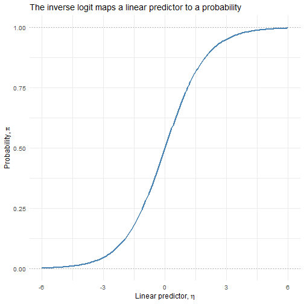

```r
logit_curve <- data.frame(eta = seq(-6, 6, length.out = 200))
logit_curve$probability <- plogis(logit_curve$eta)

ggplot(logit_curve, aes(x = eta, y = probability)) +
  geom_line(color = "steelblue", linewidth = 1) +
  geom_hline(yintercept = c(0, 1), linetype = 3, color = "grey60") +
  labs(
    title = "The inverse logit maps a linear predictor to a probability",
    x = expression(paste("Linear predictor, ", eta)),
    y = expression(paste("Probability, ", pi))
  )
```

## 3.1 必须区分的五个量

当 $x_j$ 增加一个单位、模型中的其他项保持不变时：

1. 线性预测子改变 $\beta_j$。
2. 对数优势改变 $\beta_j$。
3. 优势乘以 $\exp(\beta_j)$。
4. 概率通常**不会**改变一个固定数值。
5. 概率也**不会**乘以 $\exp(\beta_j)$。

若基线概率为 $\pi_0$，则基线优势为 $\pi_0/(1-\pi_0)$。优势比为 2 表示优势翻倍，而不是概率翻倍。新概率为

$$\pi_1=\frac{2\pi_0/(1-\pi_0)}{1+2\pi_0/(1-\pi_0)}
=\frac{2\pi_0}{1+\pi_0}.$$

对于连续预测变量，$\beta_j$ 表示每增加一个单位时，对数优势的改变量。它不是通常 log–log 模型意义下的弹性。概率对 $x_j$ 的局部斜率为 $\beta_j\pi(1-\pi)$，所以它依赖于当前概率。

## 3.2 课堂检查

提问：“优势比为 2，概率是否翻倍？还需要什么信息？”要求学生明确回答：必须知道基线概率。

## 3.3 可选语法热身：`mtcars`

`mtcars` 来自 R 基础安装中的 `datasets` 包，而不是 `dplyr` 包。这个例子适合展示公式语法和 `predict()`，但只有 32 个观测，不宜作为详细建模课的主案例。

```r
fit_cars <- glm(
  vs ~ wt + disp,
  data = mtcars,
  family = binomial(link = "logit")
)
summary(fit_cars)
```

```
##
## Call:
## glm(formula = vs ~ wt + disp, family = binomial(link = "logit"),
##     data = mtcars)
##
## Coefficients:
##             Estimate Std. Error z value Pr(>|z|)
## (Intercept)  1.60859    2.43903   0.660    0.510
## wt           1.62635    1.49068   1.091    0.275
## disp        -0.03443    0.01536  -2.241    0.025 *
## ---
## Signif. codes:  0 '***' 0.001 '**' 0.01 '*' 0.05 '.' 0.1 ' ' 1
##
## (Dispersion parameter for binomial family taken to be 1)
##
##     Null deviance: 43.86  on 31  degrees of freedom
## Residual deviance: 21.40  on 29  degrees of freedom
## AIC: 27.4
##
## Number of Fisher Scoring iterations: 6
```

```r
new_cars <- data.frame(wt = c(4, 1.8), disp = c(280, 70))
predict(fit_cars, newdata = new_cars, type = "response")
```

```
##         1         2
## 0.1783689 0.8933730
```

# 4 案例：信用卡违约

将 `default=="Yes"` 明确编码为 `default01=1`，避免模型结果隐含依赖因子水平的排列顺序。

```r
str(default_data)
```

```
## 'data.frame':    10000 obs. of  5 variables:
##  $ default  : Factor w/ 2 levels "No","Yes": 1 1 1 1 1 1 1 1 1 1 ...
##  $ student  : Factor w/ 2 levels "No","Yes": 1 2 1 1 1 2 1 2 1 1 ...
##  $ balance  : num  730 817 1074 529 786 ...
##  $ income   : num  44362 12106 31767 35704 38463 ...
##  $ default01: int  0 0 0 0 0 0 0 0 0 0 ...
```

```r
table(default_data$default, useNA = "ifany")
```

```
##
##   No  Yes
## 9667  333
```

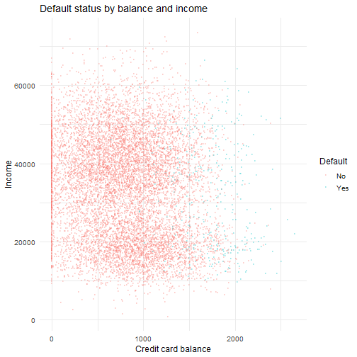

```r
ggplot(default_data, aes(x = balance, y = income, color = default)) +
  geom_point(alpha = 0.2, size = 0.8) +
  labs(
    title = "Default status by balance and income",
    x = "Credit card balance",
    y = "Income",
    color = "Default"
  )
```

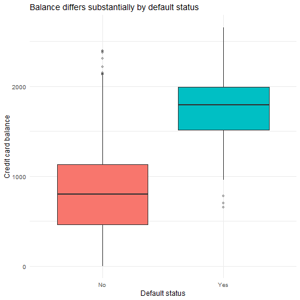

```r
ggplot(default_data, aes(x = default, y = balance, fill = default)) +
  geom_boxplot(outlier.alpha = 0.3) +
  guides(fill = "none") +
  labs(
    title = "Balance differs substantially by default status",
    x = "Default status",
    y = "Credit card balance"
  )
```

这些图用于形成预测变量的初步判断，但不能证明因果关系，也不能证明某个变量一定应进入最终模型。

## 4.1 拟合与解释

```r
fit_default <- glm(
  default01 ~ balance + student + income,
  data = default_data,
  family = binomial(link = "logit")
)
summary(fit_default)
```

```
##
## Call:
## glm(formula = default01 ~ balance + student + income, family = binomial(link = "logit"),
##     data = default_data)
##
## Coefficients:
##               Estimate Std. Error z value Pr(>|z|)
## (Intercept) -1.087e+01  4.923e-01 -22.080  < 2e-16 ***
## balance      5.737e-03  2.319e-04  24.738  < 2e-16 ***
## studentYes  -6.468e-01  2.363e-01  -2.738  0.00619 **
## income       3.033e-06  8.203e-06   0.370  0.71152
## ---
## Signif. codes:  0 '***' 0.001 '**' 0.01 '*' 0.05 '.' 0.1 ' ' 1
##
## (Dispersion parameter for binomial family taken to be 1)
##
##     Null deviance: 2920.6  on 9999  degrees of freedom
## Residual deviance: 1571.5  on 9996  degrees of freedom
## AIC: 1579.5
##
## Number of Fisher Scoring iterations: 8
```

```r
coef_default <- coef(fit_default)
or_default <- exp(cbind(OR = coef_default, confint.default(fit_default)))
or_default
```

```
##                       OR        2.5 %       97.5 %
## (Intercept) 1.903854e-05 7.254792e-06 4.996229e-05
## balance     1.005753e+00 1.005296e+00 1.006210e+00
## studentYes  5.237317e-01 3.296175e-01 8.321610e-01
## income      1.000003e+00 9.999870e-01 1.000019e+00
```

```r
balance_scaling <- data.frame(
  change = "Balance +100 currency units",
  log_odds_change = 100 * coef_default[["balance"]],
  OR = exp(100 * coef_default[["balance"]])
)
balance_scaling
```

```
##                        change log_odds_change       OR
## 1 Balance +100 currency units       0.5736505 1.774734
```

```r
income_scaling <- data.frame(
  change = "Income +10000 currency units",
  log_odds_change = 10000 * coef_default[["income"]],
  OR = exp(10000 * coef_default[["income"]])
)
income_scaling
```

```
##                         change log_odds_change       OR
## 1 Income +10000 currency units       0.0303345 1.030799
```

建议按以下顺序讲 `summary()` 输出：

1. **Estimate：** 在模型其他项不变时，每增加一个单位，对数优势的改变量。
2. **Std. Error：** 系数估计在 logit 尺度上的不确定性。
3. **z value 和 p 值：** 单个系数的 Wald 推断，不是预测重要性的度量。
4. **Null deviance 和 residual deviance：** 用于拟合模型比较，不能单独证明模型充分。
5. **AIC：** 对相同响应和相同观测所拟合模型的拟合—复杂度准则，不是绝对的拟合优度分数。

一个单位的优势比可能不便交流。应在取指数前重新缩放：例如，余额增加 100 个单位时，对数优势改变 $100\hat\beta_{\text{balance}}$，优势乘以 $\exp(100\hat\beta_{\text{balance}})$。不能把“一个单位的概率差”简单乘以或取幂来得到 100 个单位的概率变化。

## 4.2 为什么 student 的系数会改变符号

```r
fit_student_only <- glm(
  default01 ~ student,
  data = default_data,
  family = binomial(link = "logit")
)
summary(fit_student_only)$coefficients
```

```
##               Estimate Std. Error    z value     Pr(>|z|)
## (Intercept) -3.5041278 0.07071301 -49.554219 0.0000000000
## studentYes   0.4048871 0.11501883   3.520181 0.0004312529
```

```r
summary(fit_default)$coefficients
```

```
##                  Estimate   Std. Error    z value      Pr(>|z|)
## (Intercept) -1.086905e+01 4.922555e-01 -22.080088 4.911280e-108
## balance      5.736505e-03 2.318945e-04  24.737563 4.219578e-135
## studentYes  -6.467758e-01 2.362525e-01  -2.737646  6.188063e-03
## income       3.033450e-06 8.202615e-06   0.369815  7.115203e-01
```

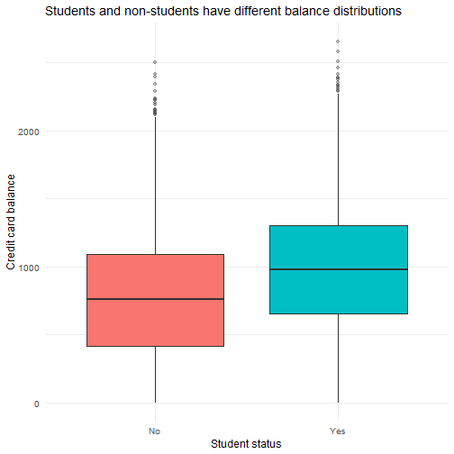

```r
ggplot(default_data, aes(x = student, y = balance, fill = student)) +
  geom_boxplot(outlier.alpha = 0.3) +
  guides(fill = "none") +
  labs(
    title = "Students and non-students have different balance distributions",
    x = "Student status",
    y = "Credit card balance"
  )
```

仅含 student 的模型估计边际关联；完整模型估计给定 balance 和 income 后的条件关联。不同学生状态的余额分布不同，因此调整后系数可能变化。应表述为“条件关联发生变化”；没有因果设计和相应假设时，不能称为 student 的因果效应。

## 4.3 预测概率与置信区间

```r
new_default <- data.frame(
  balance = 1400,
  income = 2000,
  student = factor(c("Yes", "No"), levels = levels(default_data$student))
)
pred_default_link <- predict(
  fit_default,
  newdata = new_default,
  type = "link",
  se.fit = TRUE
)
prediction_default <- data.frame(
  new_default,
  eta = pred_default_link$fit,
  probability = plogis(pred_default_link$fit),
  lower = plogis(pred_default_link$fit - 1.96 * pred_default_link$se.fit),
  upper = plogis(pred_default_link$fit + 1.96 * pred_default_link$se.fit)
)
prediction_default
```

```
##   balance income student       eta probability      lower      upper
## 1    1400   2000     Yes -3.478647  0.02992594 0.02091917 0.04264169
## 2    1400   2000      No -2.831871  0.05562603 0.03009852 0.10055950
```

先在链接尺度构造区间，再使用 `plogis()` 变换，可以保证区间端点位于 $[0,1]$。该区间是模型平均概率的置信区间，不是个体二分类结果的预测区间。这两个个体只有 student 状态不同，因此预测概率比单独看系数符号更直观地展示调整后的 student 对比。

# 5 使用 `ggplot2` 做 Logistic 诊断

诊断流程应分别回答不同问题：

| 问题 | 有用工具 | 不应得出的结论 |
| --- | --- | --- |
| 函数形式是否合适？ | 残差对预测变量或 $\hat\eta$、平滑曲线、样条比较 | $\hat\eta$ 对 $x$ 机械地呈直线，不能证明线性假设成立 |
| 是否存在异常观测？ | 标准化残差、杠杆值、Cook 距离 | 超过阈值不等于应该删除数据 |
| 预测是否校准？ | 校准图，最好使用验证数据 | 准确率高不必然表示校准好 |
| 预测变量是否冗余？ | VIF 或广义 VIF，并结合专业知识 | VIF 小于 5 不是绝对保证 |
| 观测是否独立？ | 研究设计和残差结构 | Q–Q 图不能证明独立性 |

对于二分类数据，普通 deviance 和 Pearson 残差不需要呈正态。随机分位数残差通过随机化，使其在模型正确时更便于评估分布；其 Q–Q 图是诊断辅助工具，不是模型正确性的普遍证明。

```r
set.seed(303)
diag_default <- data.frame(
  observation = seq_len(nobs(fit_default)),
  default01 = default_data$default01,
  balance = default_data$balance,
  fitted = fitted(fit_default),
  eta = predict(fit_default, type = "link"),
  deviance = residuals(fit_default, type = "deviance"),
  pearson = residuals(fit_default, type = "pearson"),
  quantile = statmod::qresid(fit_default),
  leverage = hatvalues(fit_default),
  cook = cooks.distance(fit_default)
)
```

## 5.1 残差密度：用于描述，不作最终判决

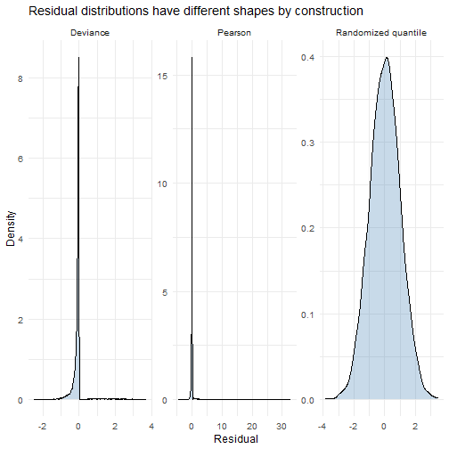

```r
residual_long <- data.frame(
  residual = c(
    diag_default$deviance,
    diag_default$pearson,
    diag_default$quantile
  ),
  type = factor(
    rep(
      c("Deviance", "Pearson", "Randomized quantile"),
      each = nrow(diag_default)
    ),
    levels = c("Deviance", "Pearson", "Randomized quantile")
  )
)

ggplot(residual_long, aes(x = residual)) +
  geom_density(fill = "steelblue", alpha = 0.3) +
  facet_wrap(~type, scales = "free") +
  labs(
    title = "Residual distributions have different shapes by construction",
    x = "Residual",
    y = "Density"
  )
```

这个 `ggplot2` 版本用分面图替代多次基础 R 的 `plot(density(...))`。教学重点是不同残差的构造与用途，而不是要求每条密度曲线都呈钟形。

## 5.2 分位数残差 Q–Q 图

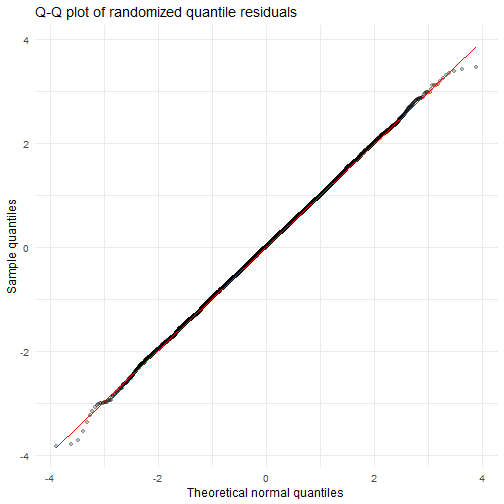

```r
ggplot(diag_default, aes(sample = quantile)) +
  stat_qq(alpha = 0.25) +
  stat_qq_line(color = "red") +
  labs(
    title = "Q-Q plot of randomized quantile residuals",
    x = "Theoretical normal quantiles",
    y = "Sample quantiles"
  )
```

不要看到 deviance 或 Pearson 残差 Q–Q 图不呈直线，就宣布 Bernoulli 响应分布错误。二分类结果会按构造产生离散、非对称的残差形态。

## 5.3 链接尺度上的函数形式

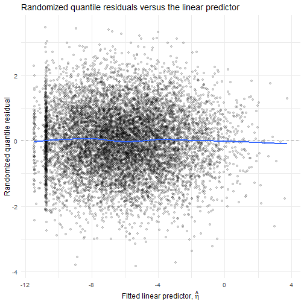

```r
ggplot(diag_default, aes(x = eta, y = quantile)) +
  geom_point(alpha = 0.15) +
  geom_hline(yintercept = 0, linetype = 2, color = "grey50") +
  geom_smooth(method = "loess", se = FALSE, formula = y ~ x, span = 0.6) +
  labs(
    title = "Randomized quantile residuals versus the linear predictor",
    x = expression(paste("Fitted linear predictor, ", hat(eta))),
    y = "Randomized quantile residual"
  )
```

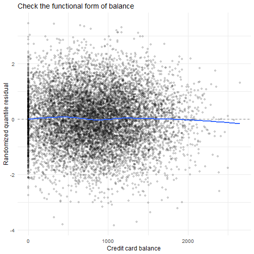

```r
ggplot(diag_default, aes(x = balance, y = quantile)) +
  geom_point(alpha = 0.15) +
  geom_hline(yintercept = 0, linetype = 2, color = "grey50") +
  geom_smooth(method = "loess", se = FALSE, formula = y ~ x, span = 0.6) +
  labs(
    title = "Check the functional form of balance",
    x = "Credit card balance",
    y = "Randomized quantile residual"
  )
```

当 `balance` 以线性项进入模型时，保持其他项不变，$\hat\eta$ 必然与 `balance` 呈线性。因此，$\hat\eta$ 对 `balance` 的直线图不能验证该假设。应观察残差是否存在系统模式，并考虑更灵活的模型。

```r
fit_default_spline <- glm(
  default01 ~ splines::ns(balance, df = 4) + student + income,
  data = default_data,
  family = binomial(link = "logit")
)
anova(fit_default, fit_default_spline, test = "LRT")
```

```
## Analysis of Deviance Table
##
## Model 1: default01 ~ balance + student + income
## Model 2: default01 ~ splines::ns(balance, df = 4) + student + income
##   Resid. Df Resid. Dev Df Deviance Pr(>Chi)
## 1      9996     1571.5
## 2      9993     1570.8  3  0.77748   0.8548
```

似然比比较提供补充证据，但不能替代图形、专业背景判断和模型验证。

## 5.4 杠杆值、影响点与多重共线性

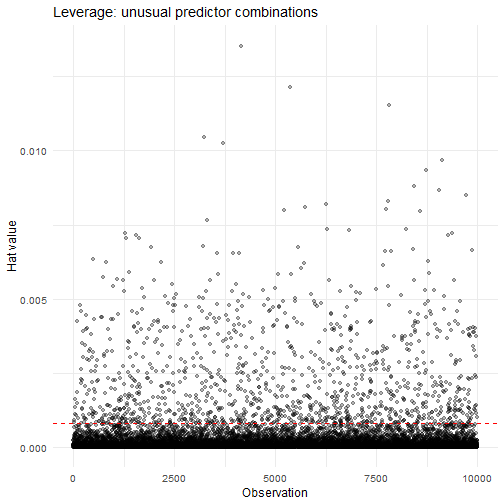

```r
p_default <- length(coef(fit_default))
n_default <- nobs(fit_default)
leverage_threshold_default <- 2 * p_default / n_default
cook_threshold_default <- 4 / n_default

ggplot(diag_default, aes(x = observation, y = leverage)) +
  geom_point(alpha = 0.3) +
  geom_hline(
    yintercept = leverage_threshold_default,
    linetype = 2,
    color = "red"
  ) +
  labs(
    title = "Leverage: unusual predictor combinations",
    x = "Observation",
    y = "Hat value"
  )
```

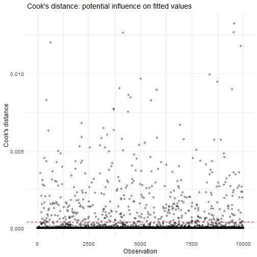

```r
ggplot(diag_default, aes(x = observation, y = cook)) +
  geom_point(alpha = 0.3) +
  geom_hline(
    yintercept = cook_threshold_default,
    linetype = 2,
    color = "red"
  ) +
  labs(
    title = "Cook's distance: potential influence on fitted values",
    x = "Observation",
    y = "Cook's distance"
  )
```

```r
top_influence_default <- head(
  diag_default[
    order(-diag_default$cook),
    c("observation", "fitted", "leverage", "cook")
  ],
  10
)
top_influence_default
```

```
##      observation       fitted     leverage        cook
## 9539        9539 0.0009233701 4.899066e-05 0.013253140
## 9523        9523 0.0055602883 2.831632e-04 0.012667879
## 4160        4160 0.0011516766 5.834825e-05 0.012652825
## 652          652 0.0019521252 9.392420e-05 0.012007228
## 9874        9874 0.9525549066 2.334366e-03 0.011771659
## 8365        8365 0.0035266082 1.406387e-04 0.009937464
## 5015        5015 0.0080747444 3.153124e-04 0.009689585
## 8725        8725 0.0384586675 1.509370e-03 0.009462839
## 3977        3977 0.9009397511 3.942983e-03 0.009036345
## 9438        9438 0.0051257666 1.851092e-04 0.008985414
```

```r
vif_default <- car::vif(fit_default)
vif_default
```

```
##  balance  student   income
## 1.076946 2.761184 2.674562
```

杠杆值关注异常的预测变量组合；大残差关注响应与拟合值的不一致；影响诊断关注观测对拟合结果的作用。三者不是同义词。$2p/n$ 和 $4/n$ 等阈值只是筛查经验。应检查数据质量并做敏感性分析，而不是自动删除观测。

## 5.5 可选校准检查

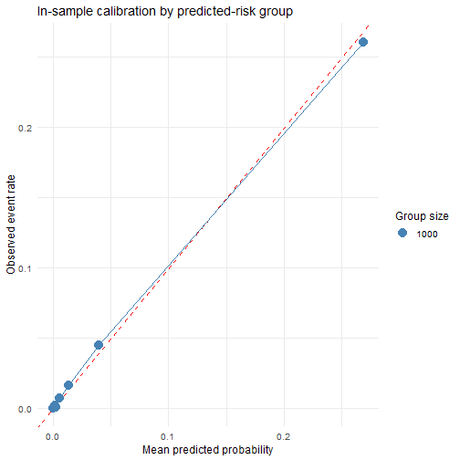

```r
calibration_breaks <- unique(quantile(
  diag_default$fitted,
  probs = seq(0, 1, by = 0.1),
  na.rm = TRUE
))
calibration_group <- cut(
  diag_default$fitted,
  breaks = calibration_breaks,
  include.lowest = TRUE
)
calibration_default <- data.frame(
  mean_predicted = tapply(diag_default$fitted, calibration_group, mean),
  observed_rate = tapply(default_data$default01, calibration_group, mean),
  n = as.integer(table(calibration_group))
)

ggplot(calibration_default, aes(x = mean_predicted, y = observed_rate)) +
  geom_abline(intercept = 0, slope = 1, linetype = 2, color = "red") +
  geom_line(color = "steelblue") +
  geom_point(aes(size = n), color = "steelblue") +
  labs(
    title = "In-sample calibration by predicted-risk group",
    x = "Mean predicted probability",
    y = "Observed event rate",
    size = "Group size"
  )
```

这里是**样本内**演示。若目标是预测，还应使用可重复的训练集／测试集划分或重抽样，并评估区分度、校准度和决策成本。残差诊断本身不能衡量样本外预测表现。

# 6 Probit 回归及与 Logit 的比较

Probit 模型为

$$P(Y_i=1\mid x_i)=\Phi(x_i^T\beta),$$

其中 $\Phi$ 是标准正态分布的分布函数。系数表示 Probit 指数的改变，而不是对数优势的改变。解释时应报告预测概率或概率差。

```r
fit_probit <- glm(
  deny01 ~ pirat,
  data = hmda,
  family = binomial(link = "probit")
)
summary(fit_probit)
```

```
##
## Call:
## glm(formula = deny01 ~ pirat, family = binomial(link = "probit"),
##     data = hmda)
##
## Coefficients:
##             Estimate Std. Error z value Pr(>|z|)
## (Intercept)  -2.1941     0.1378 -15.927  < 2e-16 ***
## pirat         2.9679     0.3858   7.694 1.43e-14 ***
## ---
## Signif. codes:  0 '***' 0.001 '**' 0.01 '*' 0.05 '.' 0.1 ' ' 1
##
## (Dispersion parameter for binomial family taken to be 1)
##
##     Null deviance: 1744.2  on 2379  degrees of freedom
## Residual deviance: 1663.6  on 2378  degrees of freedom
## AIC: 1667.6
##
## Number of Fisher Scoring iterations: 6
```

```r
fit_logit_hmda <- glm(
  deny01 ~ pirat,
  data = hmda,
  family = binomial(link = "logit")
)
summary(fit_logit_hmda)
```

```
##
## Call:
## glm(formula = deny01 ~ pirat, family = binomial(link = "logit"),
##     data = hmda)
##
## Coefficients:
##             Estimate Std. Error z value Pr(>|z|)
## (Intercept)  -4.0284     0.2686 -14.999  < 2e-16 ***
## pirat         5.8845     0.7336   8.021 1.05e-15 ***
## ---
## Signif. codes:  0 '***' 0.001 '**' 0.01 '*' 0.05 '.' 0.1 ' ' 1
##
## (Dispersion parameter for binomial family taken to be 1)
##
##     Null deviance: 1744.2  on 2379  degrees of freedom
## Residual deviance: 1660.2  on 2378  degrees of freedom
## AIC: 1664.2
##
## Number of Fisher Scoring iterations: 5
```

## 6.1 概率差的单位是“百分点”

```r
new_pirat <- data.frame(pirat = c(0.3, 0.4))
p_probit <- predict(fit_probit, newdata = new_pirat, type = "response")
probit_change <- data.frame(
  from = 0.3,
  to = 0.4,
  probability_from = unname(p_probit[1]),
  probability_to = unname(p_probit[2]),
  change_percentage_points = 100 * unname(p_probit[2] - p_probit[1])
)
probit_change
```

```
##   from  to probability_from probability_to change_percentage_points
## 1  0.3 0.4       0.09615344      0.1569678                 6.081433
```

原讲义得到的概率差约为 0.0608，应表述为“增加约 **6.08 个百分点**”，而不是“增加 6.1%”。若要表达相对百分比变化，还需要将概率差除以初始概率。

## 6.2 在同一数据、同一概率尺度上比较链接

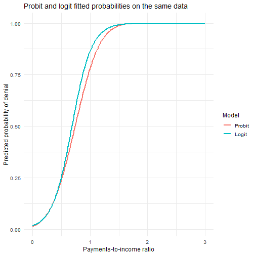

```r
pirat_grid <- data.frame(pirat = seq(
  min(hmda$pirat, na.rm = TRUE),
  max(hmda$pirat, na.rm = TRUE),
  length.out = 200
))
pirat_grid$probit <- predict(
  fit_probit,
  newdata = pirat_grid,
  type = "response"
)
pirat_grid$logit <- predict(
  fit_logit_hmda,
  newdata = pirat_grid,
  type = "response"
)
link_curve_long <- data.frame(
  pirat = rep(pirat_grid$pirat, 2),
  model = factor(
    rep(c("Probit", "Logit"), each = nrow(pirat_grid)),
    levels = c("Probit", "Logit")
  ),
  probability = c(pirat_grid$probit, pirat_grid$logit)
)

ggplot(link_curve_long, aes(x = pirat, y = probability, color = model)) +
  geom_line(linewidth = 1) +
  labs(
    title = "Probit and logit fitted probabilities on the same data",
    x = "Payments-to-income ratio",
    y = "Predicted probability of denial",
    color = "Model"
  )
```

```r
AIC(fit_probit, fit_logit_hmda)
```

```
##                df      AIC
## fit_probit      2 1667.585
## fit_logit_hmda  2 1664.188
```

不要直接比较 Logit 和 Probit 原始系数的大小，因为两者的指数尺度不同。应比较预测概率、诊断、解释便利性和验证表现。AIC 可用于同一数据上的模型比较，但不应把很小的 AIC 差异当成机械选择规则。

# 7 计数数据的 Poisson 回归

对于计数响应，

$$Y_i\mid x_i\sim\operatorname{Poisson}(\mu_i),\qquad
\log(\mu_i)=x_i^T\beta,$$

因此，在基本 Poisson 模型下，$E(Y_i\mid x_i)=\operatorname{Var}(Y_i\mid x_i)=\mu_i$。

直方图描述的是响应的**边际**分布。右偏本身不能说明给定协变量后的响应服从 Poisson；由协变量驱动的多个 Poisson 分布混合，也会产生右偏或过度离散的边际分布。

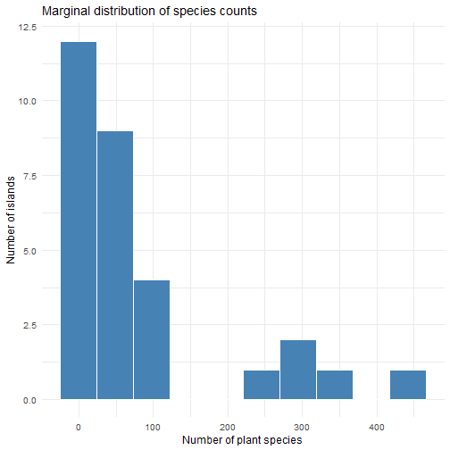

```r
ggplot(gala_data, aes(x = Species)) +
  geom_histogram(bins = 10, fill = "steelblue", color = "white") +
  labs(
    title = "Marginal distribution of species counts",
    x = "Number of plant species",
    y = "Number of islands"
  )
```

## 7.1 拟合与乘法效应解释

```r
fit_gala_full <- glm(
  Species ~ Endemics + Area + Elevation + Nearest + Scruz + Adjacent,
  data = gala_data,
  family = poisson(link = "log")
)
summary(fit_gala_full)
```

```
##
## Call:
## glm(formula = Species ~ Endemics + Area + Elevation + Nearest +
##     Scruz + Adjacent, family = poisson(link = "log"), data = gala_data)
##
## Coefficients:
##               Estimate Std. Error z value Pr(>|z|)
## (Intercept)  2.828e+00  5.958e-02  47.471  < 2e-16 ***
## Endemics     3.388e-02  1.741e-03  19.459  < 2e-16 ***
## Area        -1.067e-04  3.741e-05  -2.853  0.00433 **
## Elevation    2.638e-04  1.934e-04   1.364  0.17264
## Nearest      1.048e-02  1.611e-03   6.502 7.91e-11 ***
## Scruz       -6.835e-04  5.802e-04  -1.178  0.23877
## Adjacent     4.539e-05  4.800e-05   0.946  0.34437
## ---
## Signif. codes:  0 '***' 0.001 '**' 0.01 '*' 0.05 '.' 0.1 ' ' 1
##
## (Dispersion parameter for poisson family taken to be 1)
##
##     Null deviance: 3510.73  on 29  degrees of freedom
## Residual deviance:  313.36  on 23  degrees of freedom
## AIC: 488.19
##
## Number of Fisher Scoring iterations: 5
```

```r
fit_gala <- glm(
  Species ~ Endemics + Area + Nearest,
  data = gala_data,
  family = poisson(link = "log")
)
summary(fit_gala)
```

```
##
## Call:
## glm(formula = Species ~ Endemics + Area + Nearest, family = poisson(link = "log"),
##     data = gala_data)
##
## Coefficients:
##               Estimate Std. Error z value Pr(>|z|)
## (Intercept)  2.868e+00  4.883e-02  58.729  < 2e-16 ***
## Endemics     3.551e-02  7.327e-04  48.462  < 2e-16 ***
## Area        -4.542e-05  1.568e-05  -2.896  0.00378 **
## Nearest      9.289e-03  1.319e-03   7.043 1.88e-12 ***
## ---
## Signif. codes:  0 '***' 0.001 '**' 0.01 '*' 0.05 '.' 0.1 ' ' 1
##
## (Dispersion parameter for poisson family taken to be 1)
##
##     Null deviance: 3510.73  on 29  degrees of freedom
## Residual deviance:  330.84  on 26  degrees of freedom
## AIC: 499.67
##
## Number of Fisher Scoring iterations: 5
```

```r
irr_gala <- exp(cbind(IRR = coef(fit_gala), confint.default(fit_gala)))
irr_gala
```

```
##                    IRR      2.5 %     97.5 %
## (Intercept) 17.5995818 15.9932425 19.3672596
## Endemics     1.0361458  1.0346589  1.0376348
## Area         0.9999546  0.9999238  0.9999853
## Nearest      1.0093319  1.0067262  1.0119443
```

```r
area_effect <- data.frame(
  change = "Area +100 square km",
  IRR = exp(100 * coef(fit_gala)[["Area"]])
)
area_effect
```

```
##                change       IRR
## 1 Area +100 square km 0.9954685
```

当 $x_j$ 增加一个单位、其他模型项保持不变时，期望计数乘以 $\exp(\beta_j)$。这就是发生率比或均值比的乘法解释。对于面积等一个单位效应很小的变量，应先改成每 100 平方千米等有实际意义的尺度再解释。

这里保留精简模型是为了与原讲义对应。不要把“删除所有 $p>0.05$ 的变量”教成普遍建模策略。这样做可能扭曲统计推断，也会删除具有重要调整作用的变量。

# 8 过度离散与 quasi-Poisson

过度离散表示条件方差大于 Poisson 模型允许的方差。其后果可能包括标准误被低估、区间过窄以及显著性被夸大。

基于模型的 Pearson 离散参数估计为

$$\hat\phi=\frac{1}{n-p}\sum_{i=1}^{n}r_{P,i}^2.$$

它使用**拟合回归模型**的残差和残差自由度。将原始响应的方差与单一 Poisson 均值比较，会忽略不同协变量对应的条件均值，并不是同一种诊断。

```r
phi_gala <- pearson_dispersion(fit_gala)
phi_gala
```

```
## [1] 11.72483
```

```r
fit_gala_quasi <- update(fit_gala, family = quasipoisson(link = "log"))
summary(fit_gala_quasi)
```

```
##
## Call:
## glm(formula = Species ~ Endemics + Area + Nearest, family = quasipoisson(link = "log"),
##     data = gala_data)
##
## Coefficients:
##               Estimate Std. Error t value Pr(>|t|)
## (Intercept)  2.868e+00  1.672e-01  17.152 1.08e-15 ***
## Endemics     3.551e-02  2.509e-03  14.153 9.96e-14 ***
## Area        -4.542e-05  5.370e-05  -0.846   0.4054
## Nearest      9.289e-03  4.516e-03   2.057   0.0499 *
## ---
## Signif. codes:  0 '***' 0.001 '**' 0.01 '*' 0.05 '.' 0.1 ' ' 1
##
## (Dispersion parameter for quasipoisson family taken to be 11.72483)
##
##     Null deviance: 3510.73  on 29  degrees of freedom
## Residual deviance:  330.84  on 26  degrees of freedom
## AIC: NA
##
## Number of Fisher Scoring iterations: 5
```

```r
se_comparison_gala <- data.frame(
  term = names(coef(fit_gala)),
  poisson_se = summary(fit_gala)$coefficients[, "Std. Error"],
  quasi_poisson_se = summary(fit_gala_quasi)$coefficients[, "Std. Error"]
)
se_comparison_gala$se_ratio <-
  se_comparison_gala$quasi_poisson_se / se_comparison_gala$poisson_se
se_comparison_gala
```

```
##                    term   poisson_se quasi_poisson_se se_ratio
## (Intercept) (Intercept) 4.883194e-02     0.1672080721 3.424154
## Endemics       Endemics 7.326869e-04     0.0025088326 3.424154
## Area               Area 1.568405e-05     0.0000537046 3.424154
## Nearest         Nearest 1.318855e-03     0.0045159627 3.424154
```

对于同一个均值模型，quasi-Poisson 保持系数估计不变，并将标准误乘以 $\sqrt{\hat\phi}$。它没有提供完整的分布似然，因此普通 AIC 不可用。它也不能修复缺失预测变量、错误链接或错误函数形式。负二项模型可以作为后续扩展，但不是每个数据集的自动下一步。

# 9 使用 `ggplot2` 做 Poisson 诊断

随机分位数残差使用 Poisson 拟合对象计算；quasi-Poisson 用于离散参数调整后的 Wald 推断。两者的均值模型点估计相同。

```r
set.seed(303)
diag_gala <- data.frame(
  island = gala_data$island,
  observation = seq_len(nobs(fit_gala)),
  eta = predict(fit_gala, type = "link"),
  quantile = statmod::qresid(fit_gala),
  std_deviance = rstandard(fit_gala, type = "deviance"),
  leverage = hatvalues(fit_gala),
  cook = cooks.distance(fit_gala)
)
```

## 9.1 残差模式与 Q–Q 图

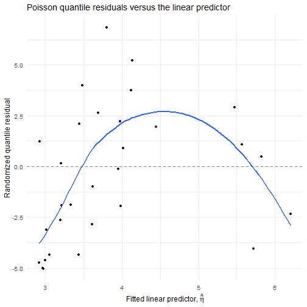

```r
ggplot(diag_gala, aes(x = eta, y = quantile)) +
  geom_point() +
  geom_hline(yintercept = 0, linetype = 2, color = "grey50") +
  geom_smooth(method = "loess", se = FALSE, formula = y ~ x, span = 0.8) +
  labs(
    title = "Poisson quantile residuals versus the linear predictor",
    x = expression(paste("Fitted linear predictor, ", hat(eta))),
    y = "Randomized quantile residual"
  )
```

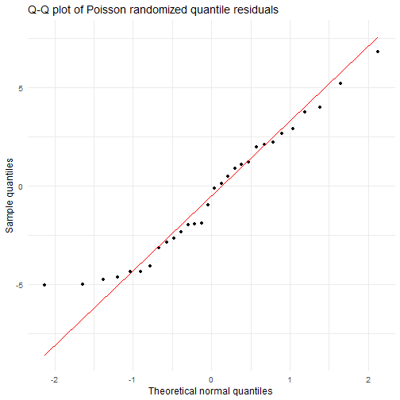

```r
ggplot(diag_gala, aes(sample = quantile)) +
  stat_qq() +
  stat_qq_line(color = "red") +
  labs(
    title = "Q-Q plot of Poisson randomized quantile residuals",
    x = "Theoretical normal quantiles",
    y = "Sample quantiles"
  )
```

只有 30 个观测时，应避免“看起来一切正常”之类的确定性表述。平滑曲线弯曲提示均值模型可能设定不当；Q–Q 图中的突出点可能对应异常观测。应进一步考虑变换、遗漏结构和敏感性分析。quasi-Poisson 本身不能消除残差曲线中的弯曲模式。

## 9.2 离群点、杠杆值与影响点

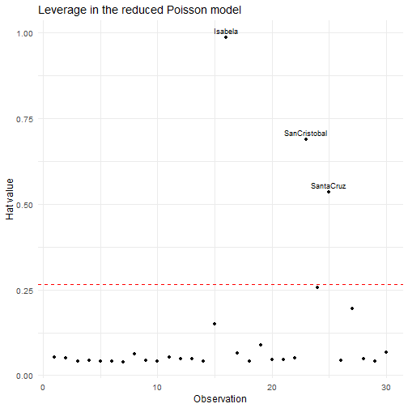

```r
p_gala <- length(coef(fit_gala))
n_gala <- nobs(fit_gala)
leverage_threshold_gala <- 2 * p_gala / n_gala
cook_threshold_gala <- 4 / n_gala

ggplot(diag_gala, aes(x = observation, y = leverage)) +
  geom_point() +
  geom_hline(
    yintercept = leverage_threshold_gala,
    linetype = 2,
    color = "red"
  ) +
  geom_text(
    data = diag_gala[diag_gala$leverage > leverage_threshold_gala, ],
    aes(label = island),
    vjust = -0.6,
    size = 3,
    check_overlap = TRUE
  ) +
  labs(
    title = "Leverage in the reduced Poisson model",
    x = "Observation",
    y = "Hat value"
  )
```

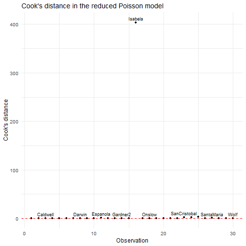

```r
ggplot(diag_gala, aes(x = observation, y = cook)) +
  geom_point() +
  geom_hline(
    yintercept = cook_threshold_gala,
    linetype = 2,
    color = "red"
  ) +
  geom_text(
    data = diag_gala[diag_gala$cook > cook_threshold_gala, ],
    aes(label = island),
    vjust = -0.6,
    size = 3,
    check_overlap = TRUE
  ) +
  labs(
    title = "Cook's distance in the reduced Poisson model",
    x = "Observation",
    y = "Cook's distance"
  )
```

```r
outliers_gala <- diag_gala[abs(diag_gala$std_deviance) > 2, ]
high_leverage_gala <-
  diag_gala[diag_gala$leverage > leverage_threshold_gala, ]
influential_gala <- diag_gala[diag_gala$cook > cook_threshold_gala, ]
outliers_gala
```

```
##                    island observation      eta   quantile std_deviance
## Baltra             Baltra           1 3.688989  2.6569269     2.736055
## Caldwell         Caldwell           3 3.000397 -4.6149095    -4.874370
## Coamano           Coamano           5 2.921029 -4.7262991    -5.024753
## Daphne.Major Daphne.Major           6 3.332755 -1.8870282    -2.068881
## Darwin             Darwin           8 3.433065 -4.3359069    -4.541039
## Eden                 Eden           9 3.013621 -3.1192529    -3.196833
## Enderby           Enderby          10 2.963033 -5.0013324    -5.170373
## Espanola         Espanola          11 3.798649  6.8336776     6.954982
## Fernandina     Fernandina          12 4.121773  3.7663498     3.802154
## Gardner1         Gardner1          13 3.481700  3.9863905     4.121713
## Gardner2         Gardner2          14 3.052599 -4.3332580    -4.320673
## Genovesa         Genovesa          15 3.982016 -1.9612829    -2.114357
## Isabela           Isabela          16 5.822503  0.4908308     4.475394
## Onslow             Onslow          18 2.969543 -5.0472671    -5.192054
## Pinta               Pinta          19 4.449258  1.9657938     2.019495
## Pinzon             Pinzon          20 4.138206  5.2119954     5.304334
## Las.Plazas     Las.Plazas          21 3.192079 -2.6410223    -2.841569
## Rabida             Rabida          22 3.973758  2.2351552     2.254739
## SanSalvador   SanSalvador          24 5.719872 -4.0510861    -4.695386
## SantaCruz       SantaCruz          25 6.205642 -2.3338938    -3.456136
## SantaMaria     SantaMaria          27 5.476334  2.9170297     3.221615
## Seymour           Seymour          28 3.441490  2.1147525     2.204806
## Wolf                 Wolf          30 3.610581 -2.8468008    -2.966373
##                leverage         cook
## Baltra       0.05190406   0.11685937
## Caldwell     0.04137989   0.16369790
## Coamano      0.04114806   0.16532551
## Daphne.Major 0.04094068   0.03984230
## Darwin       0.06244900   0.25221492
## Eden         0.04350743   0.08921699
## Enderby      0.04111487   0.17398255
## Espanola     0.05238870   0.89571481
## Fernandina   0.04881340   0.21470768
## Gardner1     0.04852747   0.26768466
## Gardner2     0.04067064   0.13645651
## Genovesa     0.15017830   0.17996910
## Isabela      0.98764758 403.97314691
## Onslow       0.04069351   0.17343098
## Pinta        0.08921355   0.10680962
## Pinzon       0.04505295   0.40447133
## Las.Plazas   0.04566081   0.07840333
## Rabida       0.04968198   0.07312494
## SanSalvador  0.25734582   1.76229993
## SantaCruz    0.53485660   3.31256786
## SantaMaria   0.19580671   0.67113018
## Seymour      0.04868676   0.07018275
## Wolf         0.06804535   0.13534946
```

```r
high_leverage_gala
```

```
##                    island observation      eta   quantile std_deviance
## Isabela           Isabela          16 5.822503  0.4908308     4.475394
## SanCristobal SanCristobal          23 5.570675  1.0911520     1.903321
## SantaCruz       SantaCruz          25 6.205642 -2.3338938    -3.456136
##               leverage       cook
## Isabela      0.9876476 403.973147
## SanCristobal 0.6889618   2.049871
## SantaCruz    0.5348566   3.312568
```

```r
influential_gala
```

```
##                    island observation      eta   quantile std_deviance
## Caldwell         Caldwell           3 3.000397 -4.6149095    -4.874370
## Coamano           Coamano           5 2.921029 -4.7262991    -5.024753
## Darwin             Darwin           8 3.433065 -4.3359069    -4.541039
## Enderby           Enderby          10 2.963033 -5.0013324    -5.170373
## Espanola         Espanola          11 3.798649  6.8336776     6.954982
## Fernandina     Fernandina          12 4.121773  3.7663498     3.802154
## Gardner1         Gardner1          13 3.481700  3.9863905     4.121713
## Gardner2         Gardner2          14 3.052599 -4.3332580    -4.320673
## Genovesa         Genovesa          15 3.982016 -1.9612829    -2.114357
## Isabela           Isabela          16 5.822503  0.4908308     4.475394
## Onslow             Onslow          18 2.969543 -5.0472671    -5.192054
## Pinzon             Pinzon          20 4.138206  5.2119954     5.304334
## SanCristobal SanCristobal          23 5.570675  1.0911520     1.903321
## SanSalvador   SanSalvador          24 5.719872 -4.0510861    -4.695386
## SantaCruz       SantaCruz          25 6.205642 -2.3338938    -3.456136
## SantaMaria     SantaMaria          27 5.476334  2.9170297     3.221615
## Wolf                 Wolf          30 3.610581 -2.8468008    -2.966373
##                leverage        cook
## Caldwell     0.04137989   0.1636979
## Coamano      0.04114806   0.1653255
## Darwin       0.06244900   0.2522149
## Enderby      0.04111487   0.1739826
## Espanola     0.05238870   0.8957148
## Fernandina   0.04881340   0.2147077
## Gardner1     0.04852747   0.2676847
## Gardner2     0.04067064   0.1364565
## Genovesa     0.15017830   0.1799691
## Isabela      0.98764758 403.9731469
## Onslow       0.04069351   0.1734310
## Pinzon       0.04505295   0.4044713
## SanCristobal 0.68896178   2.0498706
## SanSalvador  0.25734582   1.7622999
## SantaCruz    0.53485660   3.3125679
## SantaMaria   0.19580671   0.6711302
## Wolf         0.06804535   0.1353495
```

```r
vif_gala <- car::vif(fit_gala)
vif_gala
```

```
## Endemics     Area  Nearest
## 1.418635 1.389114 1.110042
```

代码明确使用 `cook=cooks.distance(fit_gala)` 计算 Cook 距离，避免原讲义中 `cooksD` 未定义的问题。所有阈值都只是筛查工具。可以在敏感性分析中重新拟合排除某个被标记观测后的模型，报告结果变化，但不能为了得到想要的结论而删除数据。

# 10 Poisson 率模型与 offset

当暴露量不同时，将期望计数写成

$$\mu_i=m_i\lambda_i,$$

其中 $m_i$ 是暴露量，$\lambda_i$ 是每单位暴露量的事件率。使用 log 链接时，

$$\log(\mu_i)=\log(m_i)+x_i^T\beta.$$

其中 $\log(m_i)$ 是 **offset**：其系数固定为 1，而不是由数据估计。响应变量仍然是计数 `cases`；不能先把响应改成比率，再声称原 Poisson 计数方差模型仍然适用。

```r
fit_rate <- glm(
  cases ~ city + age + offset(log(pop)),
  data = cancer_data,
  family = poisson(link = "log")
)
summary(fit_rate)
```

```
##
## Call:
## glm(formula = cases ~ city + age + offset(log(pop)), family = poisson(link = "log"),
##     data = cancer_data)
##
## Coefficients:
##             Estimate Std. Error z value Pr(>|z|)
## (Intercept)  -5.6321     0.2003 -28.125  < 2e-16 ***
## cityHorsens  -0.3301     0.1815  -1.818   0.0690 .
## cityKolding  -0.3715     0.1878  -1.978   0.0479 *
## cityVejle    -0.2723     0.1879  -1.450   0.1472
## age55-59      1.1010     0.2483   4.434 9.23e-06 ***
## age60-64      1.5186     0.2316   6.556 5.53e-11 ***
## age65-69      1.7677     0.2294   7.704 1.31e-14 ***
## age70-74      1.8569     0.2353   7.891 3.00e-15 ***
## age75+        1.4197     0.2503   5.672 1.41e-08 ***
## ---
## Signif. codes:  0 '***' 0.001 '**' 0.01 '*' 0.05 '.' 0.1 ' ' 1
##
## (Dispersion parameter for poisson family taken to be 1)
##
##     Null deviance: 129.908  on 23  degrees of freedom
## Residual deviance:  23.447  on 15  degrees of freedom
## AIC: 137.84
##
## Number of Fisher Scoring iterations: 5
```

```r
rr_rate <- exp(cbind(RR = coef(fit_rate), confint.default(fit_rate)))
rr_rate
```

```
##                      RR       2.5 %       97.5 %
## (Intercept) 0.003581174 0.002418625  0.005302521
## cityHorsens 0.718880610 0.503687146  1.026012546
## cityKolding 0.689667168 0.477285856  0.996553318
## cityVejle   0.761612264 0.527026991  1.100613918
## age55-59    3.007213795 1.848515376  4.892215085
## age60-64    4.565884929 2.899710957  7.189442499
## age65-69    5.857402508 3.735990951  9.183417356
## age70-74    6.403619032 4.037552548 10.156236043
## age75+      4.135686847 2.532309969  6.754270176
```

```r
phi_rate <- pearson_dispersion(fit_rate)
phi_rate
```

```
## [1] 1.504109
```

系数取指数后，在其他模型项不变时比较事件率。截距是参照城市和参照年龄组的期望对数率；除非暴露量恰为相应尺度上的 1，否则截距不是原始期望计数。

## 10.1 给定暴露量的预测

```r
new_cancer <- data.frame(
  city = factor("Kolding", levels = levels(cancer_data$city)),
  age = factor("40-54", levels = levels(cancer_data$age)),
  pop = 1000
)
pred_rate <- predict(
  fit_rate,
  newdata = new_cancer,
  type = "link",
  se.fit = TRUE
)
prediction_rate <- data.frame(
  new_cancer,
  expected_cases = exp(pred_rate$fit),
  lower = exp(pred_rate$fit - 1.96 * pred_rate$se.fit),
  upper = exp(pred_rate$fit + 1.96 * pred_rate$se.fit)
)
prediction_rate$rate_per_1000 <-
  prediction_rate$expected_cases / prediction_rate$pop * 1000
prediction_rate
```

```
##      city   age  pop expected_cases    lower    upper rate_per_1000
## 1 Kolding 40-54 1000       2.469818 1.627957 3.747029      2.469818
```

```r
offset_demo <- new_cancer[c(1, 1), ]
offset_demo$pop <- c(1000, 2000)
offset_demo$expected_cases <- predict(
  fit_rate,
  newdata = offset_demo,
  type = "response"
)
offset_demo$rate_per_1000 <-
  offset_demo$expected_cases / offset_demo$pop * 1000
offset_demo
```

```
##        city   age  pop expected_cases rate_per_1000
## 1   Kolding 40-54 1000       2.469818      2.469818
## 1.1 Kolding 40-54 2000       4.939637      2.469818
```

将链接尺度估计取指数后得到的区间是期望计数的置信区间，不是未来实际计数的预测区间；后者还需要考虑计数本身的随机变异。当 `pop=1000` 时，期望计数与每 1,000 人的事件率在数值上相同，但概念标签不同。人口翻倍时，期望计数翻倍，率保持不变。这个小演示是解释 offset 作用最直接的方式。

# 11 扩展模块 A：估计、不确定性与模型推断

本模块不属于两小时核心路线的必讲内容，但完整的 GLM 课程应当覆盖这些理论。

## 11.1 `glm()` 估计的是什么

对于参数化 GLM，通常使用极大似然法估计系数。对数似然为 $\ell(\beta)=\sum_i\ell_i(\beta)$，得分方程令其关于 $\beta$ 的导数为零。对于 logit 和 log 链接，这些方程是非线性的，通常没有闭式系数公式。

R 使用迭代加权最小二乘法（IRLS），在这里也称 Fisher scoring。直观地说，每次迭代针对一个工作响应求解加权最小二乘问题，更新 $\hat\beta$，然后重复直到估计稳定。因此，`Fisher scoring iterations` 是计算过程信息，不是模型质量指标。

在标准参数化二项和 Poisson GLM 中，离散参数固定为 1。输出中的 z 统计量使用大样本正态近似。算法收敛并不表示模型设定正确。

## 11.2 Deviance 与似然

对于拟合模型 $M$，deviance 将其对数似然与饱和参照模型比较。对固定数据集，较小的 residual deviance 表示样本内拟合更接近，但增加参数通常会降低 deviance。因此，residual deviance 不能单独作为选模规则。

常用对象包括：

- `logLik(fit)`：最大化后的对数似然。
- `deviance(fit)`：残差 deviance。
- `df.residual(fit)`：残差自由度。
- `AIC(fit)`：对于估计 $k$ 个参数的参数模型，为 $-2\ell+2k$。

```r
logLik(fit_default)
```

```
## 'log Lik.' -785.7724 (df=4)
```

```r
deviance(fit_default)
```

```
## [1] 1571.545
```

```r
df.residual(fit_default)
```

```
## [1] 9996
```

```r
AIC(fit_default)
```

```
## [1] 1579.545
```

## 11.3 Wald、轮廓似然与似然比方法

这些方法相关，但并不相同：

- **Wald 区间**使用 $\hat\beta\pm z_{1-\alpha/2}\operatorname{SE}(\hat\beta)$。计算快，在链接尺度上对称，但在稀有事件、分离或小样本下可能表现不佳。
- **轮廓似然区间**在一系列系数取值上重新优化其他参数。它可以不对称；当 Wald 近似可疑时通常更值得考虑。
- **似然比检验**比较嵌套模型的最大化似然。通常的卡方参照分布依赖正则条件和适当的参数模型。

```r
wald_ci_default <- confint.default(fit_default)
wald_ci_default
```

```
##                     2.5 %        97.5 %
## (Intercept) -1.183385e+01 -9.904242e+00
## balance      5.282000e-03  6.191010e-03
## studentYes  -1.109822e+00 -1.837294e-01
## income      -1.304338e-05  1.911028e-05
```

```r
profile_ci_default <- confint(fit_default)
profile_ci_default
```

```
##                     2.5 %        97.5 %
## (Intercept) -1.185902e+01 -9.928174e+00
## balance      5.294898e-03  6.204587e-03
## studentYes  -1.109018e+00 -1.822147e-01
## income      -1.304712e-05  1.912447e-05
```

```r
fit_default_no_income <- update(fit_default, . ~ . - income)
anova(fit_default_no_income, fit_default, test = "LRT")
```

```
## Analysis of Deviance Table
##
## Model 1: default01 ~ balance + student
## Model 2: default01 ~ balance + student + income
##   Resid. Df Resid. Dev Df Deviance Pr(>Chi)
## 1      9997     1571.7
## 2      9996     1571.5  1  0.13677   0.7115
```

```r
AIC(fit_default_no_income, fit_default)
```

```
##                       df      AIC
## fit_default_no_income  3 1577.682
## fit_default            4 1579.545
```

标准似然比比较要求模型嵌套，并且拟合使用相同响应和相同观测。AIC 比较拟合与复杂度，但不检验任何一个模型是否正确。`income` 的统计显著性也不等同于其实际重要性或预测重要性。

## 11.4 收敛、巨大系数与分离

当预测变量能够几乎完全区分两个响应类别时，会出现完全分离或准完全分离。此时有限的极大似然估计可能不存在。警示信号包括：

- 系数或标准误的绝对值异常大；
- 拟合概率极其接近 0 或 1；
- 不收敛或 IRLS 迭代次数很多；
- 出现 `fitted probabilities numerically 0 or 1 occurred` 警告。

任何单一信号都不是最终判决。应检查数据和模型，而不是仅仅隐藏警告。惩罚似然或精确方法可以作为扩展，但本文主案例不需要使用。

```r
convergence_default <- data.frame(
  converged = fit_default$converged,
  iterations = fit_default$iter,
  minimum_fitted_probability = min(fitted(fit_default)),
  maximum_fitted_probability = max(fitted(fit_default))
)
convergence_default
```

```
##   converged iterations minimum_fitted_probability maximum_fitted_probability
## 1      TRUE          8               1.025695e-05                  0.9776263
```

缺失值处理同样重要。默认情况下，`glm()` 会删除模型变量中含缺失值的行。将诊断结果合并回原数据时，如果有行被删除，应使用模型框架或明确的行标识；不能默认残差向量的位置始终与原数据一致。

# 12 扩展模块 B：分类变量、交互作用与概率尺度效应

## 12.1 处理对照与参照水平

对于使用处理对照的二水平因子，R 会为非参照水平创建指示变量。此时，当其他数值预测变量为 0 时，截距对应参照水平。`balance=0` 等取值可能不在实际关心的范围内，因此截距通常不是主要解释对象。

```r
contrasts(default_data$student)
```

```
##     Yes
## No    0
## Yes   1
```

```r
model_matrix_example <- model.matrix(
  ~ balance + student + income,
  data = default_data
)
head(model_matrix_example)
```

```
##   (Intercept)   balance studentYes    income
## 1           1  729.5265          0 44361.625
## 2           1  817.1804          1 12106.135
## 3           1 1073.5492          0 31767.139
## 4           1  529.2506          0 35704.494
## 5           1  785.6559          0 38463.496
## 6           1  919.5885          1  7491.559
```

改变参照水平会改变参数化方式，但不会改变其他条件完全等价的模型所产生的拟合概率。报告结果时，应始终说明参照类别和事件类别。

## 12.2 交互作用定义在链接尺度上

`balance*student` 展开为 `balance+student+balance:student`。交互作用允许 **logit 尺度**上的 balance 斜率随 student 状态变化。由于逆链接是非线性的，链接尺度上的交互也会产生不平行的概率曲线。

```r
fit_default_interaction <- glm(
  default01 ~ balance * student + income,
  data = default_data,
  family = binomial(link = "logit")
)
summary(fit_default_interaction)
```

```
##
## Call:
## glm(formula = default01 ~ balance * student + income, family = binomial(link = "logit"),
##     data = default_data)
##
## Coefficients:
##                      Estimate Std. Error z value Pr(>|z|)
## (Intercept)        -1.099e+01  5.667e-01 -19.399   <2e-16 ***
## balance             5.817e-03  2.938e-04  19.801   <2e-16 ***
## studentYes         -2.856e-01  8.239e-01  -0.347    0.729
## income              3.016e-06  8.226e-06   0.367    0.714
## balance:studentYes -2.184e-04  4.781e-04  -0.457    0.648
## ---
## Signif. codes:  0 '***' 0.001 '**' 0.01 '*' 0.05 '.' 0.1 ' ' 1
##
## (Dispersion parameter for binomial family taken to be 1)
##
##     Null deviance: 2920.6  on 9999  degrees of freedom
## Residual deviance: 1571.3  on 9995  degrees of freedom
## AIC: 1581.3
##
## Number of Fisher Scoring iterations: 8
```

```r
anova(fit_default, fit_default_interaction, test = "LRT")
```

```
## Analysis of Deviance Table
##
## Model 1: default01 ~ balance + student + income
## Model 2: default01 ~ balance * student + income
##   Resid. Df Resid. Dev Df Deviance Pr(>Chi)
## 1      9996     1571.5
## 2      9995     1571.3  1  0.20712    0.649
```

含交互模型中，不能把 balance 的主效应系数解释为普遍适用的 balance 效应。它是参照 student 组的斜率。应在有意义的取值范围内使用预测概率解释。

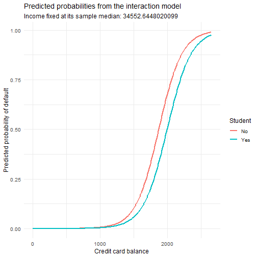

```r
balance_grid <- seq(
  min(default_data$balance),
  max(default_data$balance),
  length.out = 200
)
interaction_newdata <- expand.grid(
  balance = balance_grid,
  student = factor(
    levels(default_data$student),
    levels = levels(default_data$student)
  ),
  income = median(default_data$income)
)
interaction_newdata$probability <- predict(
  fit_default_interaction,
  newdata = interaction_newdata,
  type = "response"
)

ggplot(
  interaction_newdata,
  aes(x = balance, y = probability, color = student)
) +
  geom_line(linewidth = 1) +
  labs(
    title = "Predicted probabilities from the interaction model",
    subtitle = paste("Income fixed at its sample median:", median(default_data$income)),
    x = "Credit card balance",
    y = "Predicted probability of default",
    color = "Student"
  )
```

将 `income` 固定在中位数，得到的是条件于某一明确收入水平的曲线，并不是对观测收入分布取平均后的结果。

## 12.3 平均概率对比

对每个观测行，分别计算 `student=Yes` 和 `student=No` 时的模型预测概率，其他变量保持不变。对每一行的概率差取平均，得到平均调整后概率对比。

```r
default_yes <- default_data
default_yes$student <- factor(
  "Yes",
  levels = levels(default_data$student)
)
default_no <- default_data
default_no$student <- factor(
  "No",
  levels = levels(default_data$student)
)
p_if_yes <- predict(fit_default, newdata = default_yes, type = "response")
p_if_no <- predict(fit_default, newdata = default_no, type = "response")
average_student_contrast <- mean(p_if_yes - p_if_no)
average_student_contrast
```

```
## [1] -0.01326965
```

这是在样本协变量分布上平均的模型关联性摘要，不自动具有因果含义。其标准误需要额外方法，例如 delta 方法或适当的 bootstrap。

对于无交互 Logistic 模型中的连续预测变量，第 $i$ 个观测处的导数为 $\beta_j\hat\pi_i(1-\hat\pi_i)$。对该导数取平均，可得到概率尺度上的平均边际效应。

```r
average_balance_slope <- coef(fit_default)[["balance"]] *
  mean(fitted(fit_default) * (1 - fitted(fit_default)))
average_balance_slope_per_100 <- 100 * average_balance_slope
average_balance_slope_per_100
```

```
## [1] 0.01232347
```

每 100 个单位的平均斜率是局部概率尺度摘要。它不等于从一个固定概率变化到另一个固定概率，也不是优势比。

# 13 扩展模块 C：样本外预测评估

## 13.1 先划分数据，再评估

模型诊断关注假设和函数形式是否合理；预测评估关注模型在未参与拟合的观测上表现如何。预测项目需要二者，任何一方都不能替代另一方。

下面代码进行可重复、近似按类别分层的划分。实际项目中，所有依赖数据的预处理、变量选择和阈值调整都只能使用训练数据。

```r
stratified_training_rows <- function(y, proportion = 0.7) {
  rows_by_class <- split(seq_along(y), y)
  selected <- unlist(
    lapply(rows_by_class, function(rows) {
      sample(rows, size = floor(length(rows) * proportion))
    }),
    use.names = FALSE
  )
  sort(selected)
}

set.seed(303)
training_rows <- stratified_training_rows(default_data$default01)
training_data <- default_data[training_rows, ]
test_data <- default_data[-training_rows, ]

fit_default_train <- glm(
  default01 ~ balance + student + income,
  data = training_data,
  family = binomial(link = "logit")
)
p_test <- predict(fit_default_train, newdata = test_data, type = "response")
observed_test <- test_data$default01
```

单次划分可能不稳定。模型开发时通常更适合交叉验证或重复重抽样。最终保留的测试集不应被反复用于选择变量、链接或阈值。

## 13.2 混淆矩阵与依赖阈值的指标

以违约为阳性类别：

- 灵敏度或召回率为 $TP/(TP+FN)$；
- 特异度为 $TN/(TN+FP)$；
- 精确率为 $TP/(TP+FP)$；
- 准确率为 $(TP+TN)/N$。

类别不平衡时，准确率可能具有误导性。始终预测“不违约”的分类器可能有很高准确率，但灵敏度为零。

```r
predicted_test <- as.integer(p_test >= 0.5)
confusion_test <- table(
  Observed = factor(observed_test, levels = c(0, 1)),
  Predicted = factor(predicted_test, levels = c(0, 1))
)
confusion_test
```

```
##         Predicted
## Observed    0    1
##        0 2888   13
##        1   70   30
```

```r
tn <- confusion_test["0", "0"]
fp <- confusion_test["0", "1"]
fn <- confusion_test["1", "0"]
tp <- confusion_test["1", "1"]
accuracy_test <- (tp + tn) / sum(confusion_test)
sensitivity_test <- tp / (tp + fn)
specificity_test <- tn / (tn + fp)
precision_test <- tp / (tp + fp)
brier_test <- mean((observed_test - p_test)^2)
p_test_clamped <- pmin(pmax(p_test, 1e-15), 1 - 1e-15)
log_loss_test <- -mean(
  observed_test * log(p_test_clamped) +
    (1 - observed_test) * log(1 - p_test_clamped)
)

prediction_metrics <- data.frame(
  metric = c(
    "Accuracy", "Sensitivity", "Specificity", "Precision",
    "Brier score", "Log loss"
  ),
  value = c(
    accuracy_test, sensitivity_test, specificity_test, precision_test,
    brier_test, log_loss_test
  )
)
prediction_metrics
```

```
##        metric      value
## 1    Accuracy 0.97234255
## 2 Sensitivity 0.30000000
## 3 Specificity 0.99551879
## 4   Precision 0.69767442
## 5 Brier score 0.02354585
## 6    Log loss 0.08903948
```

Brier 分数是概率误差的均方，越小越好。Log loss 对自信但错误的概率预测惩罚很重，越小越好。它们直接评估概率；准确率、灵敏度、特异度和精确率则依赖所选阈值。

## 13.3 ROC 与精确率—召回率曲线

ROC 曲线展示阈值变化时灵敏度与假阳性率的关系。ROC AUC 衡量排序区分度，不衡量校准。AUC 很高并不表示预测概率等于实际事件率。

事件稀少时，精确率—召回率曲线尤其有信息。其精确率基线是事件发生率，不同于 ROC 图中的对角随机线。

下面的实现只在每个相同预测分数区段的末尾计算阈值点，因此能够正确处理并列分数。

```r
binary_prediction_curves <- function(y, p) {
  stopifnot(
    length(y) == length(p),
    all(y %in% c(0, 1)),
    all(is.finite(p)),
    sum(y == 1) > 0,
    sum(y == 0) > 0
  )
  ordering <- order(p, decreasing = TRUE)
  p_sorted <- p[ordering]
  y_sorted <- y[ordering]
  tp_cumulative <- cumsum(y_sorted == 1)
  fp_cumulative <- cumsum(y_sorted == 0)
  tie_end <- !duplicated(p_sorted, fromLast = TRUE)
  tp_at_threshold <- tp_cumulative[tie_end]
  fp_at_threshold <- fp_cumulative[tie_end]
  thresholds <- p_sorted[tie_end]
  positives <- sum(y == 1)
  negatives <- sum(y == 0)

  roc <- data.frame(
    fpr = c(0, fp_at_threshold / negatives),
    tpr = c(0, tp_at_threshold / positives),
    threshold = c(Inf, thresholds)
  )
  pr <- data.frame(
    recall = c(0, tp_at_threshold / positives),
    precision = c(1, tp_at_threshold / (tp_at_threshold + fp_at_threshold)),
    threshold = c(Inf, thresholds)
  )
  list(roc = roc, pr = pr)
}

curves_test <- binary_prediction_curves(observed_test, p_test)
roc_test <- curves_test$roc
pr_test <- curves_test$pr
```

下面的梯形法利用单调递增的假阳性率序列计算经验 ROC 曲线下面积。

```r
auc_test <- sum(
  diff(roc_test$fpr) *
    (head(roc_test$tpr, -1) + tail(roc_test$tpr, -1)) / 2
)
auc_test
```

```
## [1] 0.9333264
```

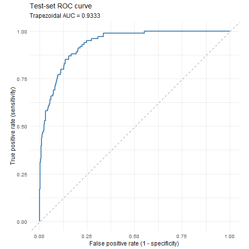

```r
ggplot(roc_test, aes(x = fpr, y = tpr)) +
  geom_abline(intercept = 0, slope = 1, linetype = 2, color = "grey50") +
  geom_line(color = "steelblue", linewidth = 1) +
  coord_equal(xlim = c(0, 1), ylim = c(0, 1)) +
  labs(
    title = "Test-set ROC curve",
    subtitle = paste("Trapezoidal AUC =", round(auc_test, 4)),
    x = "False positive rate (1 - specificity)",
    y = "True positive rate (sensitivity)"
  )
```

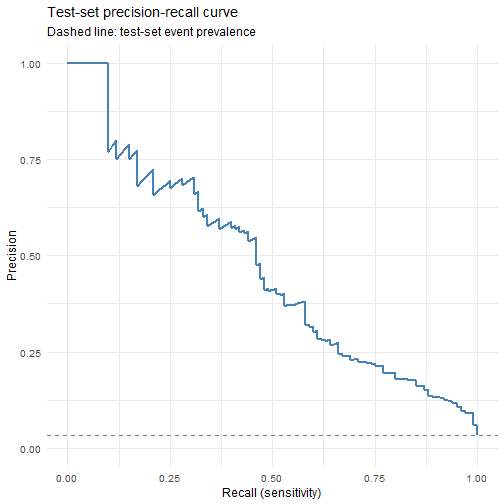

```r
ggplot(pr_test, aes(x = recall, y = precision)) +
  geom_hline(
    yintercept = mean(observed_test),
    linetype = 2,
    color = "grey50"
  ) +
  geom_line(color = "steelblue", linewidth = 1) +
  coord_cartesian(xlim = c(0, 1), ylim = c(0, 1)) +
  labs(
    title = "Test-set precision-recall curve",
    subtitle = "Dashed line: test-set event prevalence",
    x = "Recall (sensitivity)",
    y = "Precision"
  )
```

阈值应反映决策成本，并在训练集或验证集上确定，而不是为了在最终测试集上取得最好表现而选择。校准、区分度和临床或金融效用是不同性质。

# 14 扩展模块 D：Poisson 模型的进一步评估

## 14.1 过度离散下的嵌套比较

普通 Poisson 似然比检验假设 Poisson 方差模型成立。存在明显过度离散时，名义卡方参照可能产生过于激进的 p 值。下面的比较用于展示 R 语法和模型差异；确认过度离散后，不能天真地解释这些结果。

```r
anova(fit_gala, fit_gala_full, test = "LRT")
```

```
## Analysis of Deviance Table
##
## Model 1: Species ~ Endemics + Area + Nearest
## Model 2: Species ~ Endemics + Area + Elevation + Nearest + Scruz + Adjacent
##   Resid. Df Resid. Dev Df Deviance  Pr(>Chi)
## 1        26     330.84
## 2        23     313.36  3   17.482 0.0005625 ***
## ---
## Signif. codes:  0 '***' 0.001 '**' 0.01 '*' 0.05 '.' 0.1 ' ' 1
```

```r
AIC(fit_gala, fit_gala_full)
```

```
##               df      AIC
## fit_gala       4 499.6684
## fit_gala_full  7 488.1868
```

这里的 AIC 比较同一数据上的两个参数化 Poisson 拟合，不包含 quasi-Poisson 离散参数修正。quasi-Poisson 没有普通完整似然，因此没有普通 AIC。

## 14.2 灵活的函数形式

残差平滑曲线弯曲可能来自遗漏的非线性项、遗漏预测变量、交互作用或影响点。样条是一种诊断性替代方案，不是自动修复办法。

```r
fit_gala_spline <- update(
  fit_gala,
  . ~ Endemics + splines::ns(Area, df = 3) + Nearest
)
anova(fit_gala, fit_gala_spline, test = "LRT")
```

```
## Analysis of Deviance Table
##
## Model 1: Species ~ Endemics + Area + Nearest
## Model 2: Species ~ Endemics + splines::ns(Area, df = 3) + Nearest
##   Resid. Df Resid. Dev Df Deviance  Pr(>Chi)
## 1        26     330.84
## 2        24     222.98  2   107.86 < 2.2e-16 ***
## ---
## Signif. codes:  0 '***' 0.001 '**' 0.01 '*' 0.05 '.' 0.1 ' ' 1
```

```r
AIC(fit_gala, fit_gala_spline)
```

```
##                 df      AIC
## fit_gala         4 499.6684
## fit_gala_spline  6 395.8094
```

只有 30 个岛屿时，增加灵活性必须权衡方差和稳定性。不能因为某种变换产生理想的 p 值就选择它。应绘制拟合关系并检查科学合理性。

## 14.3 留一敏感性分析

影响点应触发数据核查和敏感性分析。下面代码识别最大 Cook 距离对应的观测，重新拟合排除该行后的模型并比较系数。主分析中的观测不会被静默删除。

```r
most_influential_island <- diag_gala$island[which.max(diag_gala$cook)]
fit_gala_leave_one_out <- update(
  fit_gala,
  data = gala_data[gala_data$island != most_influential_island, ]
)
coefficient_sensitivity <- data.frame(
  term = names(coef(fit_gala)),
  full_model = coef(fit_gala),
  leave_one_out = coef(fit_gala_leave_one_out)
)
coefficient_sensitivity$change <-
  coefficient_sensitivity$leave_one_out - coefficient_sensitivity$full_model
most_influential_island
```

```
## [1] "Isabela"
```

```r
coefficient_sensitivity
```

```
##                    term    full_model leave_one_out        change
## (Intercept) (Intercept)  2.8678751411  2.7778550554 -0.0900200857
## Endemics       Endemics  0.0355078212  0.0405436376  0.0050358164
## Area               Area -0.0000454177 -0.0005819772 -0.0005365595
## Nearest         Nearest  0.0092886047  0.0099687311  0.0006801264
```

系数变化很大表示结论高度依赖一个观测。应检查数值是否错误、模型是否缺少结构，以及该观测是否属于科学上不同的子群。

## 14.4 quasi-Poisson 不足时怎么办

以下情况应考虑更多建模：

- 离散参数调整后，均值结构仍然弯曲；
- 零计数多于 Poisson 均值模型所能解释的数量；
- 观测存在聚类或重复测量，独立性不成立；
- 需要过度离散计数分布的完整似然。

负二项、零膨胀或 hurdle、混合效应模型分别处理不同问题。它们不是“过度离散”的可互换同义词，每种模型都需要自己的诊断与解释。

# 15 扩展模块 E：率模型诊断

原讲义跳过了最后率模型的诊断。这里使用同样的结构化流程：检查残差模式、随机分位数残差、异常观测、影响点和离散程度。offset 改变期望计数尺度，但不会消除诊断的必要性。

```r
set.seed(303)
diag_rate <- data.frame(
  observation = seq_len(nobs(fit_rate)),
  group = paste(cancer_data$city, cancer_data$age, sep = " / "),
  eta = predict(fit_rate, type = "link"),
  quantile = statmod::qresid(fit_rate),
  std_deviance = rstandard(fit_rate, type = "deviance"),
  leverage = hatvalues(fit_rate),
  cook = cooks.distance(fit_rate)
)
```

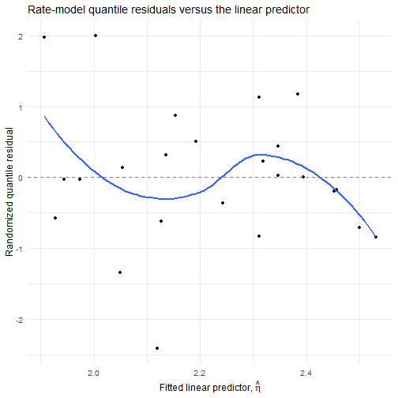

```r
ggplot(diag_rate, aes(x = eta, y = quantile)) +
  geom_point() +
  geom_hline(yintercept = 0, linetype = 2, color = "grey50") +
  geom_smooth(method = "loess", se = FALSE, formula = y ~ x, span = 0.9) +
  labs(
    title = "Rate-model quantile residuals versus the linear predictor",
    x = expression(paste("Fitted linear predictor, ", hat(eta))),
    y = "Randomized quantile residual"
  )
```

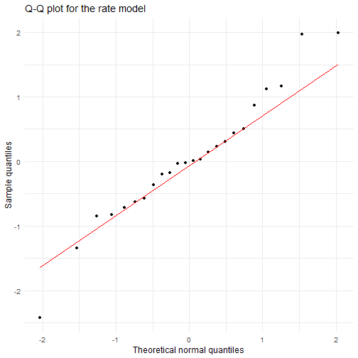

```r
ggplot(diag_rate, aes(sample = quantile)) +
  stat_qq() +
  stat_qq_line(color = "red") +
  labs(
    title = "Q-Q plot for the rate model",
    x = "Theoretical normal quantiles",
    y = "Sample quantiles"
  )
```

只有 24 个城市—年龄组，因此图形和数值标记都应谨慎解释。group 标签同时包含城市和年龄，便于追踪被标记的观测。

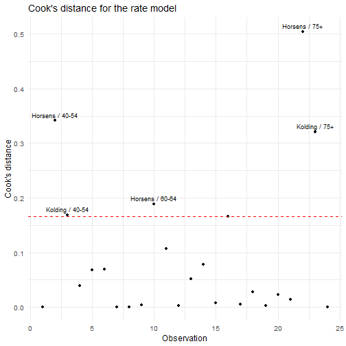

```r
leverage_threshold_rate <- 2 * length(coef(fit_rate)) / nobs(fit_rate)
cook_threshold_rate <- 4 / nobs(fit_rate)

ggplot(diag_rate, aes(x = observation, y = cook)) +
  geom_point() +
  geom_hline(
    yintercept = cook_threshold_rate,
    linetype = 2,
    color = "red"
  ) +
  geom_text(
    data = diag_rate[diag_rate$cook > cook_threshold_rate, ],
    aes(label = group),
    vjust = -0.6,
    size = 3,
    check_overlap = TRUE
  ) +
  labs(
    title = "Cook's distance for the rate model",
    x = "Observation",
    y = "Cook's distance"
  )
```

```r
rate_flags <- diag_rate[
  abs(diag_rate$std_deviance) > 2 |
    diag_rate$leverage > leverage_threshold_rate |
    diag_rate$cook > cook_threshold_rate,
]
rate_flags
```

```
##    observation           group      eta  quantile std_deviance  leverage
## 2            2 Horsens / 40-54 2.003074  1.994804     2.261199 0.3286998
## 3            3 Kolding / 40-54 2.049004 -1.346489    -1.848879 0.3509565
## 10          10 Horsens / 60-64 2.384117  1.169152     1.528771 0.3937242
## 22          22   Horsens / 75+ 2.119384 -2.420076    -3.326994 0.3723796
## 23          23   Kolding / 75+ 1.906766  1.972143     2.218757 0.3219538
##         cook
## 2  0.3414624
## 3  0.1686580
## 10 0.1889755
## 22 0.5048607
## 23 0.3208806
```

不要把 residual deviance 除以其自由度当成机械的通过／不通过检验。应综合考察离散程度、残差模式、影响点和研究设计。

# 16 练习与参考答案

## 16.1 概念练习

1. **优势与概率。** 基线概率为 0.10，优势比为 2。新概率是多少？  
   **答案：** 基线优势为 $0.1/0.9=1/9$；翻倍后为 $2/9$；新概率为 $(2/9)/(1+2/9)=2/11\approx0.1818$。概率没有翻倍。
2. **尺度转换。** Logistic 的 balance 系数以每个货币单位估计。如何得到 100 个单位的优势比？  
   **答案：** 计算 $\exp(100\hat\beta)$，不是 $100\exp(\hat\beta)$，也不是概率变化。
3. **预测类型。** Logistic 模型中，哪个 `predict()` 类型返回对数优势？  
   **答案：** `type="link"`；`type="response"` 返回概率。
4. **符号变化。** 为什么 `studentYes` 在仅含 student 的模型和调整模型中可能符号相反？  
   **答案：** 两者估计不同的边际关联和条件关联，而且不同 student 状态的 balance 分布不同。
5. **Probit 单位。** 预测概率从 0.20 增加到 0.26。绝对变化是多少？  
   **答案：** 0.06，即 6 个百分点。相对增加为 $0.06/0.20=30\%$。
6. **Poisson 解释。** log 链接 Poisson 模型中，$\exp(\beta_j)$ 表示什么？  
   **答案：** 其他模型项不变时，$x_j$ 增加一个单位，期望计数乘以该值；存在暴露量 offset 时，对应期望率的乘法变化。
7. **Quasi-Poisson。** 系数、标准误和普通 AIC 哪些会改变？  
   **答案：** 同一均值模型的系数不变；标准误乘以 $\sqrt{\hat\phi}$；普通 AIC 不可用。
8. **Offset。** 协变量不变而暴露量翻倍时，期望计数和期望率如何变化？  
   **答案：** 期望计数翻倍；期望率不变。
9. **诊断。** 对于以线性项进入模型的预测变量，$\hat\eta$ 对该变量的图为直线，能否证明线性假设？  
   **答案：** 不能，这是模型公式决定的。应检查残差模式和灵活替代模型。
10. **预测。** ROC AUC 很高的模型是否仍可能校准很差？  
    **答案：** 是。排序区分度和概率校准是不同性质。

## 16.2 编程练习

1. 改变 student 的参照水平后重新拟合 `fit_default`，验证拟合概率不变。
2. 将 0.5 分类阈值改为根据训练数据中的成本计算确定的阈值，最终测试集保持不参与选择。
3. 排除影响最大的岛屿后重新拟合 `fit_gala`，比较系数和预测计数。
4. 拟合不含 offset 的率模型，并解释其系数回答的是另一个问题。
5. 使用测试集预测概率而不是样本内拟合值绘制校准图。
6. 综合专业背景、残差图和预测表现比较完整与精简 Poisson 模型，而不是只看 p 值。

# 17 最终建模检查清单

报告 GLM 之前，逐项检查：

- **问题：** 目标是推断、预测，还是二者兼有？
- **响应：** 二分类、分组二项、计数，还是与率有关的计数？
- **事件编码：** 1 究竟代表什么？
- **分类变量：** 参照水平是什么？
- **链接与尺度：** 系数在哪个尺度上是线性的？
- **暴露量：** 是否需要 offset？
- **依赖性：** 观测在设计上是否独立？
- **函数形式：** 连续预测变量的形式是否合适？
- **离散程度：** 均值—方差关系是否合理？
- **异常数据：** 是否理解残差、杠杆值和影响诊断的发现？
- **不确定性：** Wald 近似是否合理，是否需要基于似然的替代方法？
- **预测：** 性能与阈值决策是否避免了测试集信息泄漏？
- **交流：** 是否始终区分优势、概率、计数、率、百分比和百分点？

# 18 总结与出门测

让学生不看输出，完成以下四句话：

1. Logistic 回归中，`coef()` 位于 ______ 尺度，`exp(coef())` 给出 ______。
2. Probit 回归中，0.06 的概率差是 ______ 个百分点。
3. Poisson 回归中，`exp(coef())` 表示 ______ 的乘法变化。
4. 率模型中，响应变量仍然是 ______，`offset(log(exposure))` 的系数固定为 ______。

参考答案：对数优势；优势比；6；期望均值或率，视具体项而定；计数；1。

最后不要给学生留下“选择 p 值最小的模型”这种印象。应强调：先明确响应与暴露量，再识别解释尺度，使用基于模型的诊断，并以有实际意义的单位报告预测及不确定性。

## 18.1 一分钟板书总结

课程最后保留以下四组对应关系：

- Logistic：$\hat\beta$ → 对数优势；$\exp(\hat\beta)$ → 优势比。
- Probit：$\hat\beta$ → 正态指数变化；使用预测概率解释。
- Poisson：$\hat\beta$ → 对数期望计数；$\exp(\hat\beta)$ → 均值比或率比。
- Offset：$\log(\text{暴露量})$ 的系数固定为 1；响应变量仍然是计数。

# 19 教师附录：原讲义需要更仔细的地方

| 原讲义问题 | 为什么需要修正或补充 | 本文档的处理 |
| --- | --- | --- |
| 将 `mtcars` 说成来自 `dplyr` | 它实际来自 `datasets` | 已更正，并降为可选语法示例 |
| 讲优势比时没有回答概率如何变化 | 优势与概率之间是非线性关系 | 加入基线概率换算公式与课堂检查 |
| 将连续变量系数称为弹性 | 这不是通常 log–log 模型中的弹性 | 改为对数优势变化和局部概率斜率 |
| 将 p 值当作预测重要性或删变量规则 | 统计显著性与预测目标不同 | 加入尺度转换、调整分析和建模目标提醒 |
| 强调二分类模型的残差正态性 | Bernoulli 数据不要求残差正态 | 分残差类型解释，并加入随机分位数残差 |
| 用 $\hat\eta$ 对 `balance` 的图证明线性 | 该直线由模型公式机械决定 | 改为残差平滑图和样条比较 |
| 将 Probit 的概率变化写成 6.1% | 0.061 的概率差是 6.1 个百分点 | 更正单位，并区分相对百分比变化 |
| 仅凭计数右偏就称为近似 Poisson | 边际右偏不能验证条件 Poisson 模型 | 加入条件均值—方差关系 |
| 用原始响应检查回归中的过度离散 | 回归中每个观测有不同的拟合均值 | 改为拟合模型的 Pearson 离散参数 |
| 将 quasi-Poisson 当作通用解决办法 | 它调整不确定性，不修正均值模型 | 加入局限及 AIC 不可用的原因 |
| 使用未定义的 `cooksD` | 代码不能独立运行 | 明确调用 `cooks.distance()` |
| 率模型的数据整理依赖外部向量 | 代码脆弱，也掩盖暴露量含义 | 在模型公式中使用 `offset(log(pop))` |
| 混合预测、分类和诊断 | 估计、阈值选择与验证是不同任务 | 分开讲解概率、诊断、校准和验证 |